# Duplicate Violation Entries

```python
from glob import glob
import pandas
import sqlalchemy
import psycopg2
import os
import gc
import re
import numpy as np
import matplotlib.pyplot as plt
import seaborn as sns
import gmaps
import json
import ast
from matplotlib.cm import viridis
from matplotlib.colors import to_hex
gmaps.configure(api_key="AIzaSyCxPYF3iX86sQSkGZDq-VMVZHPSxlZDuKU")
con = psycopg2.connect(host='kickstart.ctdadytx5qfc.us-east-1.rds.amazonaws.com',user='mpazoles',port=5432,database='kcmo')
```

### Duplicate entries of the same violation

From our discussions, we noted that inspectors will mark a violation as closed and open a new violation of the same kind in order to trigger a new letter for the owner. This would lead to more violations being reported as closed in a shorter time frame than are actually being closed.

```python
inspections_to_close = pandas.read_sql("select inspections_to_close, count(*) from property_violations_training group by 1 order by 1", con)
inspections_to_close.head()
```

|  | inspections_to_close | count |
| --- | --- | --- |
| 0 | 0 | 1008 |
| 1 | 1 | 176086 |
| 2 | 2 | 35491 |
| 3 | 3 | 9659 |
| 4 | 4 | 2875 |

Within each case, we can look for evidence of this practice by finding violations that are opened on the same date as a violation of the same description was closed. Though this would also include legitimate cases where a different violation of the same kind was found, this is the best method available to separate out these potential duplicates.

select a.property_violation_id, a.inspection_area, a.id as open_id, b.id as close_id, a.violation_description, a.ordinance_chapter, a.inspections_to_close as itc_a, b.inspections_to_close as itc_b, a.inspections_to_close+b.inspections_to_close as combined_inspections_to_close, a.violation_entry_date, b.violation_closed_date from pazoles.property_violations_training a left join pazoles.property_violations_training b on a.property_violation_id = b.property_violation_id and a.violation_description=b.violation_description and a.violation_closed_date = b.violation_entry_date and a.id <> b.id where b.id is not null order by property_violation_id, violation_description, violation_entry_date

```python
duplicates_pass1 = pandas.read_sql("select a.property_violation_id,a.id as open_id, b.id as close_id, a.inspection_area, a.violation_description, a.ordinance_chapter, a.inspections_to_close as itc_a, b.inspections_to_close as itc_b, a.inspections_to_close+b.inspections_to_close as combined_inspections_to_close, a.violation_entry_date, b.violation_closed_date from pazoles.property_violations_training a left join pazoles.property_violations_training b on a.property_violation_id = b.property_violation_id and a.violation_description=b.violation_description and a.violation_closed_date = b.violation_entry_date and a.id <> b.id where b.id is not null order by property_violation_id, violation_description, violation_entry_date",con)
duplicates_pass1.groupby('combined_inspections_to_close')['property_violation_id'].count()
```

```
combined_inspections_to_close
1        96
2     29271
3     10550
4      4097
5      1541
6       577
7       240
8        88
9        32
10       24
11        3
12        2
13        1
Name: property_violation_id, dtype: int64
```

Table `a` shows the initial violations

```python
duplicates_pass1.groupby('itc_a')['property_violation_id'].count()
```

```
itc_a
0         1
1     35943
2      7580
3      2111
4       657
5       161
6        43
7        20
8         4
9         1
10        1
Name: property_violation_id, dtype: int64
```

Table `b` shows the second violation of the same type

```python
duplicates_pass1.groupby('itc_b')['property_violation_id'].count()
```

```
itc_b
0      111
1    36853
2     7073
3     1752
4      509
5      151
6       54
7       15
8        4
Name: property_violation_id, dtype: int64
```

Since this is a nonstandard use of the data entry process, there may be an "inspector effect" where this tactic is being used more frequently.

```python
dupe_areas = duplicates_pass1.groupby('inspection_area')['property_violation_id'].count().sort_values(ascending=False)
dupe_areas.describe()
```

```
count     228.000000
mean      203.964912
std       357.462790
min         1.000000
25%        17.750000
50%        57.000000
75%       199.250000
max      2706.000000
Name: property_violation_id, dtype: float64
```

```python
violations = pandas.read_sql("select * from property_violations_training",con)
violation_areas = violations.groupby('inspection_area')['property_violation_id'].count()
violation_areas.describe()
```

```
count     241.000000
mean      940.170124
std      1413.711940
min         1.000000
25%       141.000000
50%       367.000000
75%      1075.000000
max      9433.000000
Name: property_violation_id, dtype: float64
```

```python
((dupe_areas/violation_areas).sort_values(ascending=False)*100).describe()
```

```
count    228.000000
mean      15.811541
std        6.853139
min        1.798561
25%       11.247692
50%       14.839840
75%       20.446721
max       37.329700
Name: property_violation_id, dtype: float64
```

Above, we calculated the number of duplicate entries by violation area called `dupe_areas` and created a similar list called `violations` so that we can calculate if this is due to higher volume or if it is being used as a tactic more frequently.

```python
high_percentage = (dupe_areas/violation_areas).sort_values(ascending=False)[:20]
high_percentage
```

```
inspection_area
66     0.373297
28     0.344547
63     0.337687
125    0.311661
55     0.305608
118    0.305211
64     0.299536
62     0.296984
20     0.286865
51     0.284062
126    0.281638
27     0.280612
130    0.277019
32     0.275862
54     0.273536
117    0.273512
30     0.266269
53     0.263717
154    0.262317
46     0.259475
Name: property_violation_id, dtype: float64
```

```python
high_volume = dupe_areas.sort_values(ascending=False)[:20]
high_volume
```

```
inspection_area
20     2706
30     1874
129    1607
59     1447
118    1429
19     1303
28     1229
18     1223
119    1199
128    1123
17      948
21      897
58      800
29      777
69      777
64      774
54      738
34      737
63      698
31      681
Name: property_violation_id, dtype: int64
```

The prevalence of duplicates does appear to grow relative to the number of violations in a given area, but there are some clear outliers. With more data on inspector case history, we might be able to derive further insights.

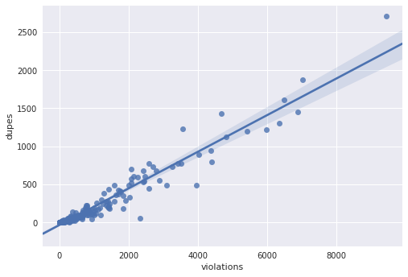

```python
df = pandas.DataFrame({'dupes':dupe_areas,'violations':violation_areas}).fillna(0)
sns.regplot(y=df.dupes,x=df.violations)
plt.show()
```

```python
(high_volume + high_percentage).sort_values(ascending=False,na_position='last')
```

```
inspection_area
20     2706.286865
30     1874.266269
118    1429.305211
28     1229.344547
64      774.299536
54      738.273536
63      698.337687
117            NaN
119            NaN
125            NaN
126            NaN
128            NaN
129            NaN
130            NaN
```

[output cut: 20 more lines]

After redistributing the duplicates:

```python
inspections_to_close = pandas.read_sql("select inspections_to_close, count(*) from property_violations_training group by 1 order by 1", con)
inspections_to_close
```

|  | inspections_to_close | count |
| --- | --- | --- |
| 0 | 0 | 896 |
| 1 | 1 | 114503 |
| 2 | 2 | 43099 |
| 3 | 3 | 14089 |
| 4 | 4 | 4960 |
| 5 | 5 | 1805 |
| 6 | 6 | 728 |
| 7 | 7 | 342 |
| 8 | 8 | 109 |
| 9 | 9 | 52 |
| 10 | 10 | 38 |
| 11 | 11 | 3 |
| 12 | 12 | 12 |
| 13 | 13 | 1 |